# Modeling thermal trade-offs versus trade-ups in a Resistance-vs-Recovery framework

Hermina

```r
library(deSolve) # for solving ordinary differential equations
library(vegan) # to estimate diversity
library(tidyverse) # for everything
```

# Motivation

As summarized in the introduction of [Logan et al., 2019](https://onlinelibrary.wiley.com/doi/full/10.1111/evo.13862), there’s 2 main hypotheses for thermal performance: thermodynamic effect (hereafter called “hotter is better”) and specialist-generalist trade-off. The 2 are not mutually exclusive. Both hypotheses describe how the full thermal performance curve of 2 (or more) species are related.

In our experiment, we are **not** interested in the full thermal performance curve. We’re only interested in what happens at the very extreme end of temperature. So we can summarize the effect of interest under a null hypothesis and two alternative hypotheses in the following schematics:

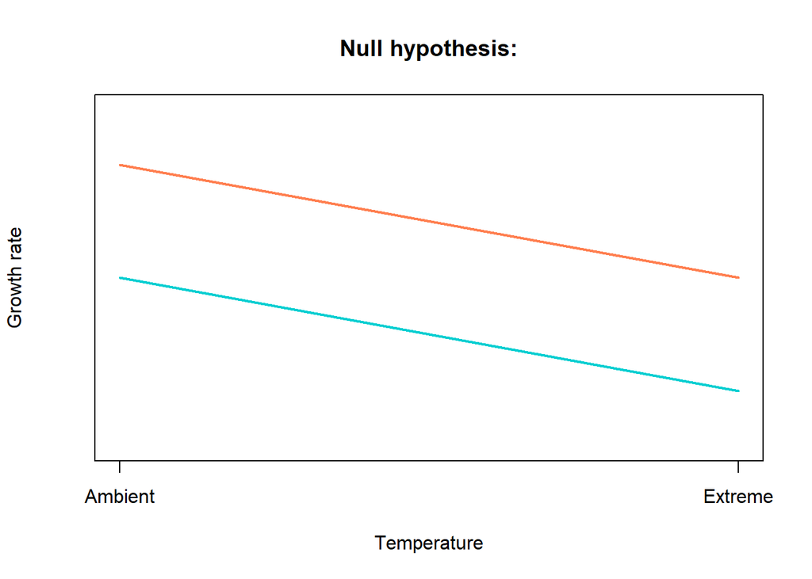

```r
plot_muSchematic <- function(fast_ambient, fast_extreme, slo_ambient, slo_extreme,
                             plot_title){
  plot(x=1:2, y=c(fast_ambient, fast_extreme),
       type = "n", xaxt = "n", ylim = c(-1, 2), yaxt = "n",
       xlab = "Temperature", ylab = "Growth rate", main=plot_title)
  # Add custom x-axis labels
  axis(1, at = c(1, 2), labels = c("Ambient", "Extreme"))
  # Draw the two lines
  lines(x=1:2, y=c(fast_ambient, fast_extreme), col="coral", lwd = 2)
  lines(x=1:2, y=c(slo_ambient, slo_extreme), col="darkturquoise", lwd = 2)
}


# make plot for no effect:
plot_muSchematic(slo_ambient = 0.5, slo_extreme = -0.5, fast_ambient = 1.5, fast_extreme = 0.5,
                 plot_title = "Null hypothesis:")
```

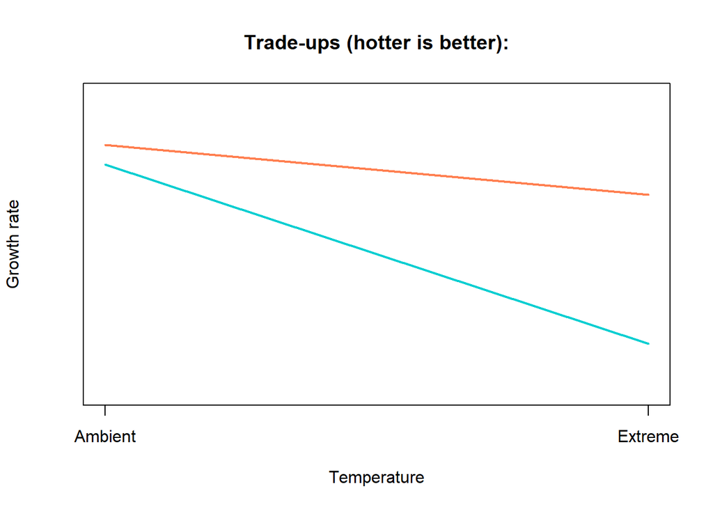

```r
# make plot for Trade-Ups:
plot_muSchematic(slo_ambient = 1.3, slo_extreme = -0.5, fast_ambient = 1.5, fast_extreme = 1,
                 plot_title = "Trade-ups (hotter is better):")
```

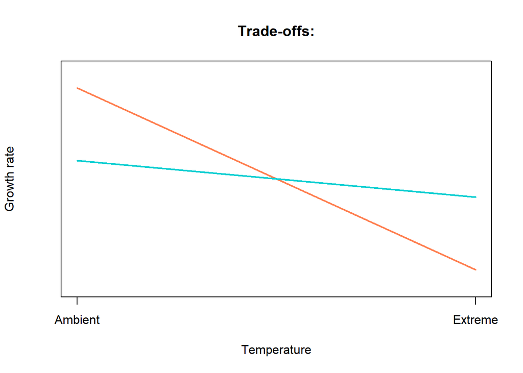

```r
# make plot for Trade-Offs:
plot_muSchematic(slo_ambient = 0.75, slo_extreme = 0.25, fast_ambient = 1.75, fast_extreme = -0.75,
                 plot_title = "Trade-offs:")
```

The question is: how do these different hypotheses map onto Maddy’s Resistance-Recovery framework? And what do we expect to see under each of these hypotheses as we increase the duration of the heat pulse event?

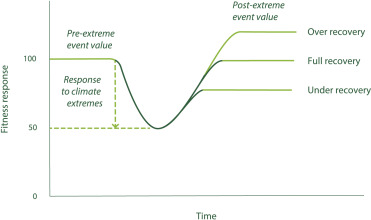

Note that when we are talking about resistance and recovery we mean the effect size between the heat pulse treatment versus a no-heat control. More specifically, we are referring to the effect size based on differences between means (e.g., I used the emmeans function `eff_size` in my analysis of the flow cytometry data and this estimates Cohen’s d, a standardized mean difference). In the toy models below, everything is fully deterministic and the population is uniform so the populations do not exhibit any variation and we’re able to get the mean just from the one simulated value.

# The Model

I think it is sufficient to consider a model of Logistic growth with multiple species $i$, where each species has population size $n_i$: $\frac{1}{n_i} \frac{dn_i}{dt} = \mu_i(T)(1-\frac{\Sigma n_i}{K})$.

Growth rate is an explicit function of temperature ($\mu_i(T)$) but as we have a pulse perturbation, we’re actually only interested in two growth rates for each species: that at ambient temperature and at the extreme temperature. The ambient growth rates we have already measured so that’s fine. The trouble is that the growth rates are negative for extreme temperatures but we cannot measure death… Anyway we can still eye-ball things.

Finally, we assume that carrying capacity is temperature and species independent. We can estimate the carrying capacity from the control treatment because the temperature stays constant at its ambient value.

For starters, we have just 2 species in the community.

Note that our model does not include extinction (i.e.,the population can approach 0 but it won’t ever actually reach it). This should hardly impact the total productivity, except when both species have large negative growth rates during the heat pulse (in which case the effect size of productivity will tend to $\rightarrow -\infty$ instead of plateauing off at some negative fixed value as determined by the no-heat control). I think the lack of extinctions will more often impact the diversity estimate because, even if there is a really big difference in the growth rates between the two species, it’s never possible for one to drive the other to extinction. So this means that instead of having diversity reach 0, it will go to small values, thus producing negative values of the effect size that can even $\rightarrow -\infty$ depending on the no-heat control…

19 Dec Notes: I think it’s worthwhile to simplify the model even further (for now) by considering only exponential growth. That’s because we have no antagonistic interactions in the model, it’s just competition on density-dependent growth rate. So we can get an idea of how the batch culture results will look like by simulating less time for exponential growth. Then I can more quickly test if my intuition about resistance/recovery make sense before I bother to specify the batch culture model.

16 Jan Notes: Actually I don’t think it will work properly without a carrying capacity. Also: it might be nice to make a little shiny of the simple model just to play around.

26 Jan Notes: After analyzing the toy model, I’ve decided that the coupling and decoupling framework proposed by Maddy is just not useful for understanding community resilience given how we are defining the effect sizes.

## Building the model

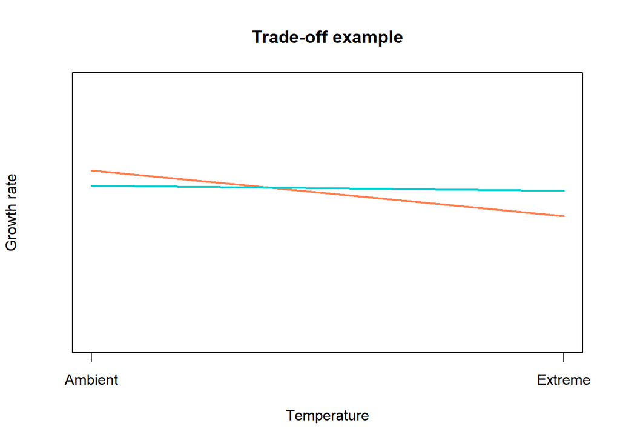

```r
# define the set of ordinary differential equations
ODE_2sp <- function(time, init, params){
  with (as.list(c(time, init, params)), {
    dN1_dt = N1 * mu1 * (1 - (N1 + N2)/K)
    dN2_dt = N2 * mu2 * (1 - (N1 + N2)/K)
    return(list(c(dN1 = dN1_dt, dN2 = dN2_dt)))
  })
}

# a function to simulate the community for a constant temperature
sim_1temp <- function(time, init, params) {
  # solve the system of ODE's for the requested time points:
  sim <- ode(func = ODE_2sp, y = init, parms = params, times = time, method="ode23")
  # make a long data.frame with trees and grass over time
  return(data.frame(sim))
}

# a function to simulate a pulse perturbation
sim_pulse <- function(times, # a vector of length 3: when extreme heat starts, when it stops, and total time
                      mu_ambient, # a named vector of length 2: mu1 and m2
                      mu_extreme, # a named vector of length 2: mu1 and m2
                      K,
                      init # a named vector of length 2: N1 and N2
                      ) {
  # simulate the time at ambient temperature before the start of the heat pulse
  sim <- sim_1temp(time = 0:times[1],
                   init = init,
                   params = c(K=K, mu_ambient["mu1"], mu_ambient["mu2"]))

  # then simulate the heat pulse itself and append it to the simulation results
  sim <- rbind(sim[-(times[1]+1),], # remove final value of previous simulation bc it's redundant
               sim_1temp(time = times[1]:times[2], # from beginning to end of heat pulse
                         init = unlist(sim[(times[1]+1),-1]), # initialize from the final values of the previous simulation
                         params = c(K=K, mu_extreme["mu1"], mu_extreme["mu2"])) # use the growth rates during extreme heat
               )

  # finally simulate the recovery after heat pulse and append it to the results
  sim <- rbind(sim[-(times[2]+1),],
               sim_1temp(time = times[2]:times[3], # from end of heat pulse to end of time
                         init = unlist(sim[(times[2]+1),-1]),
                         params = c(K=K, mu_ambient["mu1"], mu_ambient["mu2"])) # growth rates at ambient
               )

  return(sim)
}

# TO DO: a function to simulate serial transfers with/out pulse perturbations
sim_serialTransf <- function(trmt) {
  # check that trmt has an allowed value
  stopifnot(trmt %in% c("ctrl", "6h", "12h", "24h", "48h"))

  #
}


# a function to get the effect size
heatVScontrol_effect <- function(simdata_heat, # output from sim_pulse
                                 simdata_control # output from sim_1temp for corresponding no-heat control
                                 ) {
  # initialize the data.frame for output
  out_df <- simdata_heat

  # get the effect size for each of the 2 species population sizes
  out_df$N1 <- simdata_heat$N1 - simdata_control$N1
  out_df$N2 <- simdata_heat$N2 - simdata_control$N2

  # get the effect size on total productivity
  out_df$productivity <- out_df$N1 + out_df$N2

  # get the effect size on Shannon diversity
  div_heat <- diversity(simdata_heat[,-1], index = "shannon")
  div_control <- diversity(simdata_control[,-1], index = "shannon")
  out_df$diversity <- div_heat - div_control

  return(out_df)
}

##################################################

# let's try out an example
State <- c(N1=0.001, N2=0.001)
heat_pulse_times <- c(5,18,30)
carrying_cap <- 10^6
sp1_ambient <- 0.99
sp1_extreme <- 0.46
sp2_ambient <- 0.81
sp2_extreme <- 0.75

plot_muSchematic(fast_ambient = sp1_ambient, fast_extreme = sp1_extreme,
                 slo_ambient = sp2_ambient, slo_extreme = sp2_extreme,
                 plot_title = "Trade-off example")
```

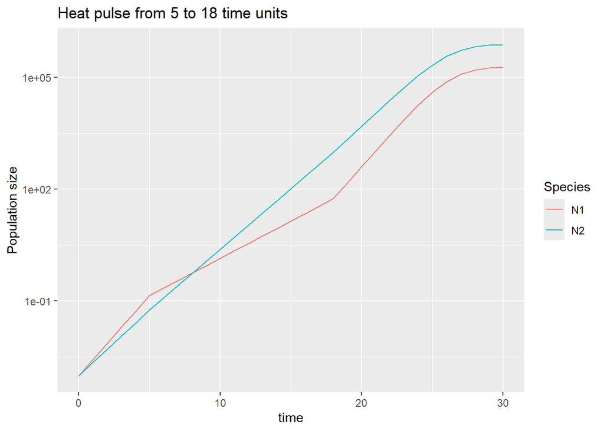

```r
# simulate the community with heat pulse
simEX <- sim_pulse(times=heat_pulse_times, init=State, K=carrying_cap,
                   mu_ambient=c(mu1=sp1_ambient, mu2=sp2_ambient), mu_extreme=c(mu1=sp1_extreme, mu2=sp2_extreme))

# plot the example under heat pulse conditions
ggplot(pivot_longer(simEX, cols = N1:N2),
       aes(x=time, y=value, colour=name)) +
  geom_line() +
  labs(title = "Heat pulse from 5 to 18 time units", y="Population size", colour = "Species") +
  scale_y_log10()
```

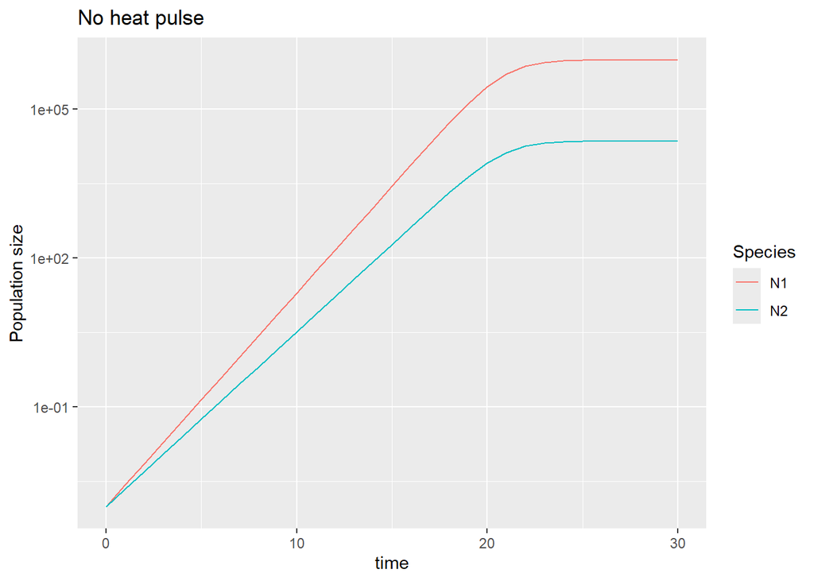

```r
# simulate the community WITHOUT heat pulse (i.e., no heat control)
simCTRL <- sim_1temp(time = 0:heat_pulse_times[3],
                   init = State,
                   params = c(K=carrying_cap, mu1=sp1_ambient, mu2=sp2_ambient))
# plot the no heat control:
ggplot(pivot_longer(simCTRL, cols = N1:N2),
       aes(x=time, y=value, colour=name)) +
  geom_line() +
  labs(title = "No heat pulse", y="Population size", colour = "Species") +
  scale_y_log10()
```

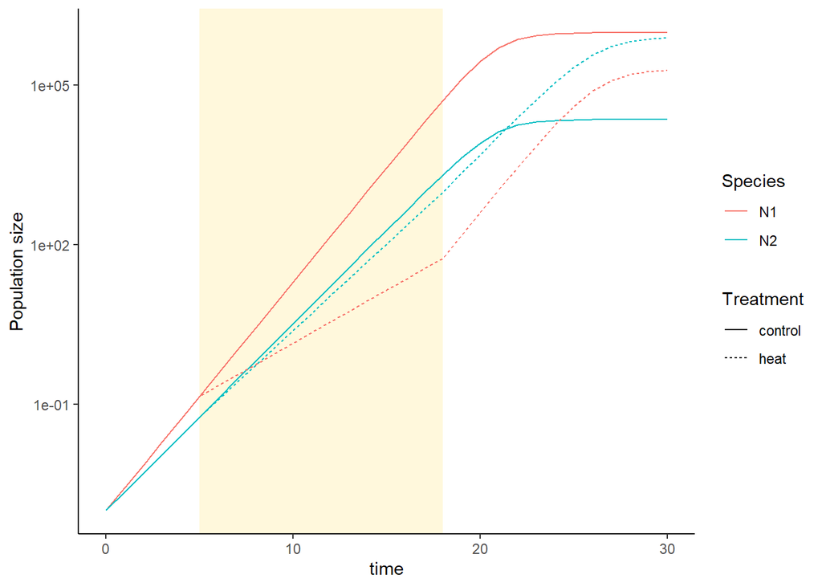

```r
# put the 2 treatments on the same plot
temp.df <- rbind(data.frame(pivot_longer(simEX, cols = N1:N2), trmt="heat"),
                 data.frame(pivot_longer(simCTRL, cols = N1:N2), trmt="control"))
ggplot(temp.df,
       aes(x=time, y=value, group=paste(trmt, name))) +
  geom_rect(aes(xmin=5, xmax=18, ymin=0, ymax=Inf), fill="cornsilk") +
  geom_line(aes(linetype=trmt, colour=name)) +
  scale_y_log10() +
  labs(linetype="Treatment", colour="Species",
       y="Population size") +
  theme_classic()
```

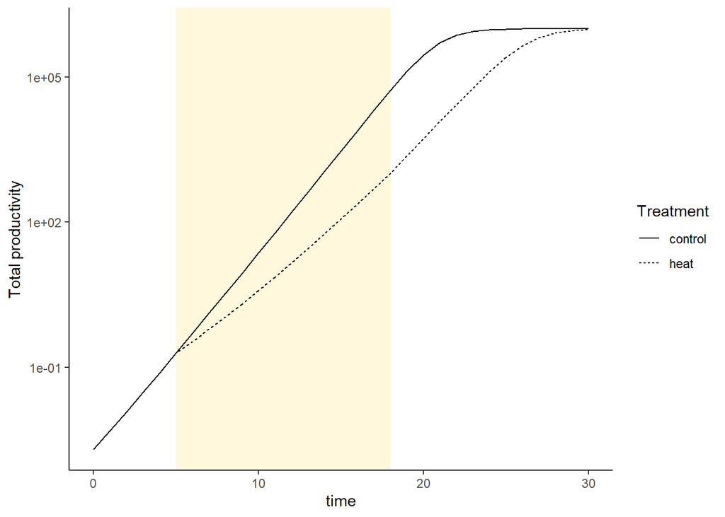

```r
# put the total productivity both treatments on the same plot
temp.df <- rbind(data.frame(simEX %>% mutate(productivity = N1+N2, .keep="unused"),
                            trmt="heat"),
                 data.frame(simCTRL %>% mutate(productivity = N1+N2, .keep="unused"),
                            trmt="control"))
ggplot(temp.df,
       aes(x=time, y=productivity, group=trmt)) +
  geom_rect(aes(xmin=5, xmax=18, ymin=0, ymax=Inf), fill="cornsilk") +
  geom_line(aes(linetype=trmt)) +
  scale_y_log10() +
  labs(linetype="Treatment",
       y="Total productivity") +
  theme_classic()
```

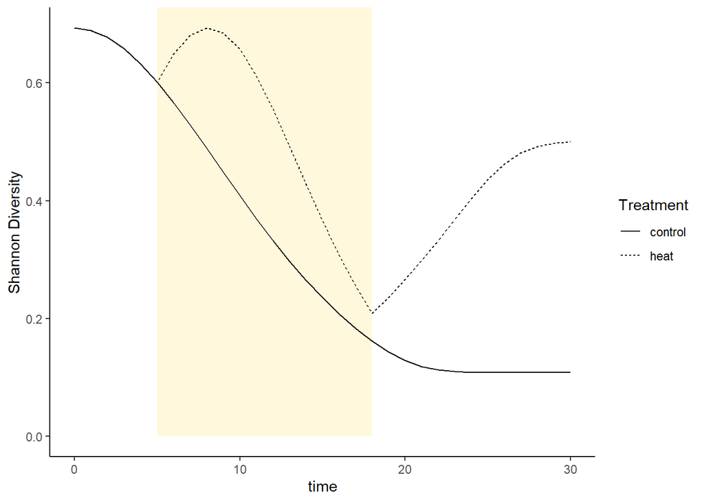

```r
# finally, put the diversity both treatments on the same plot
temp.df <- rbind(data.frame(time = simEX$time,
                            div = diversity(simEX[,-1], index="shannon"),
                            trmt="heat"),
                 data.frame(time = simCTRL$time,
                            div = diversity(simCTRL[,-1], index="shannon"),
                            trmt="control"))
ggplot(temp.df,
       aes(x=time, y=div, group=trmt)) +
  geom_rect(aes(xmin=5, xmax=18, ymin=0, ymax=Inf), fill="cornsilk") +
  geom_line(aes(linetype=trmt)) +
  labs(linetype="Treatment",
       y="Shannon Diversity") +
  theme_classic()
```

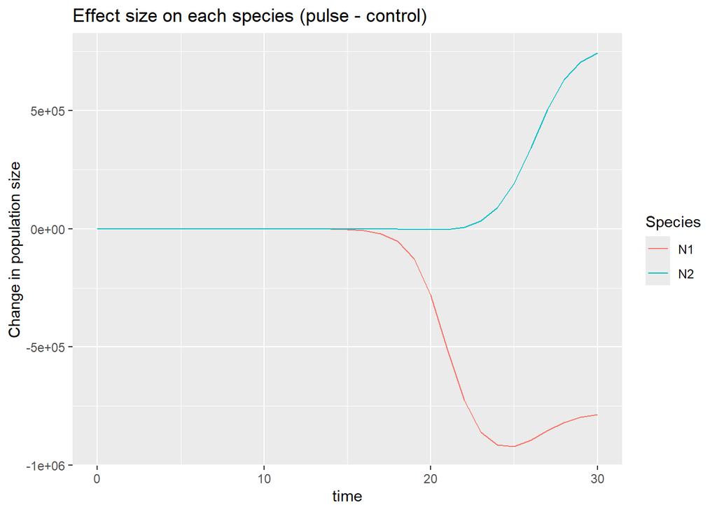

```r
rm(temp.df)

################ let's look at the effect size in different ways:
effects_df <- heatVScontrol_effect(simdata_heat=simEX, simdata_control=simCTRL)

# plot per species
ggplot(effects_df %>%
         select(time, N1, N2) %>% pivot_longer(cols = N1:N2),
       aes(x=time, y=value, colour=name)) +
  geom_line() +
  labs(title = "Effect size on each species (pulse - control)", y="Change in population size", colour = "Species")
```

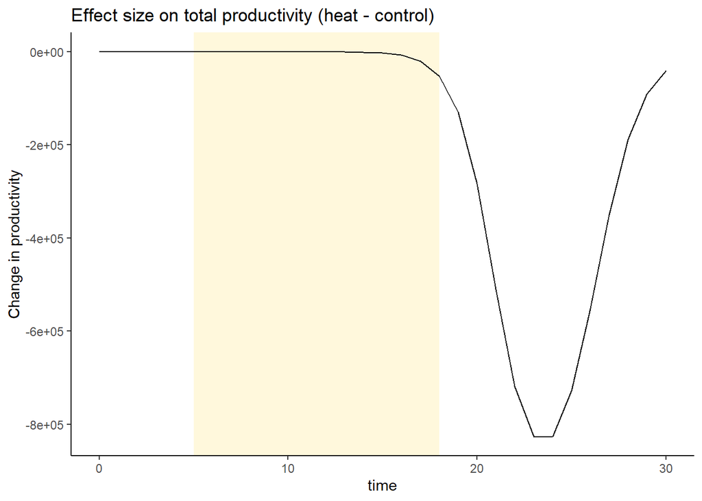

```r
# total productivity
ggplot(effects_df %>%
         select(time, productivity),
       aes(x=time, y=productivity)) +
  geom_rect(aes(xmin=5, xmax=18, ymin=-Inf, ymax=Inf), fill="cornsilk") +
  geom_line() +
  labs(title = "Effect size on total productivity (heat - control)", y="Change in productivity") +
  theme_classic()
```

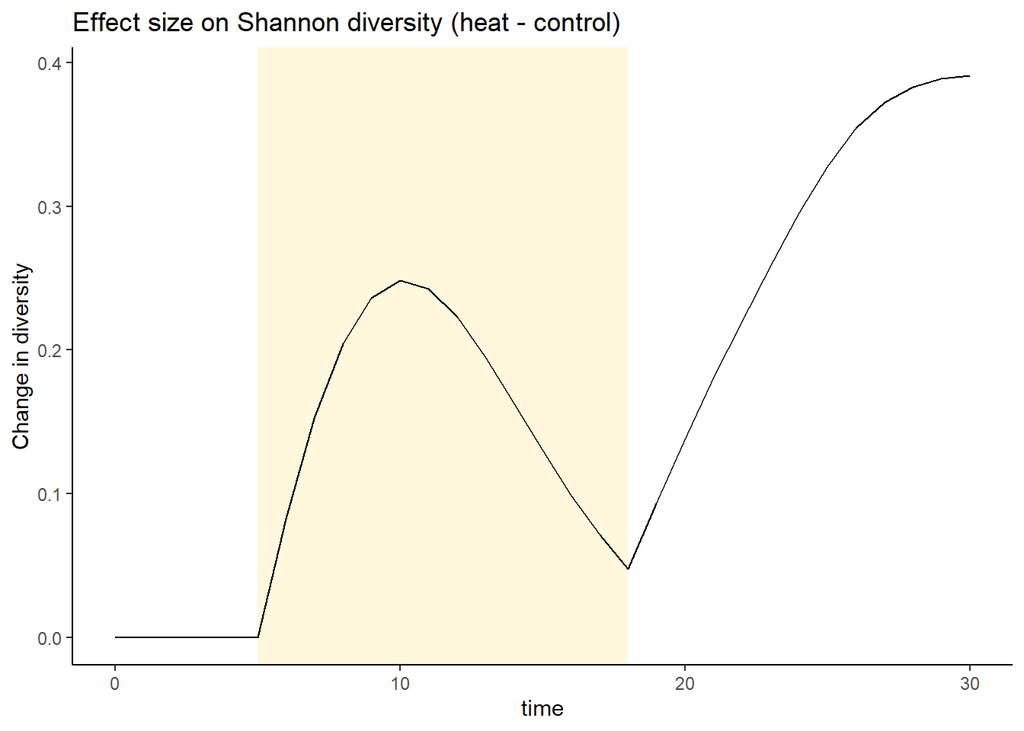

```r
# Shannon diversity
ggplot(effects_df %>%
         select(time, diversity),
       aes(x=time, y=diversity)) +
  geom_rect(aes(xmin=5, xmax=18, ymin=-Inf, ymax=Inf), fill="cornsilk") +
  geom_line() +
  labs(title = "Effect size on Shannon diversity (heat - control)", y="Change in diversity") +
  theme_classic()
```

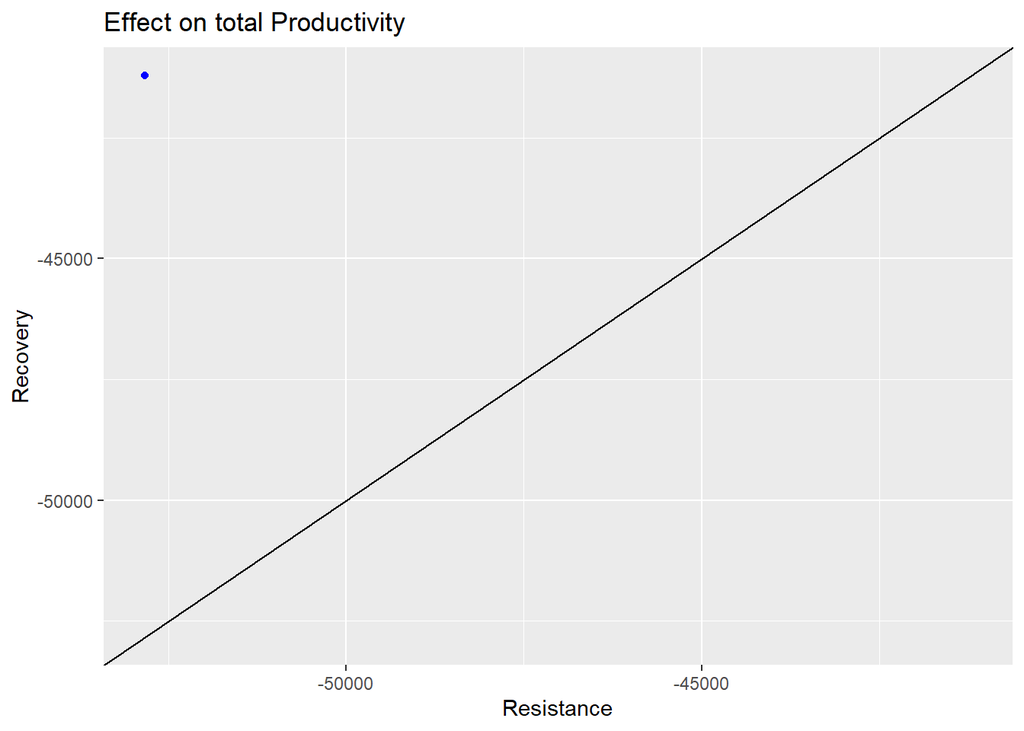

```r
################ finally, we can plot resistance vs recovery
temp_df <- data.frame(prod_resist = effects_df$productivity[which(effects_df$time == heat_pulse_times[2])],
prod_recov = effects_df$productivity[which(effects_df$time == heat_pulse_times[3])])

ggplot(temp_df, aes(x = prod_resist, y = prod_recov)) +
  geom_point(color = "blue") +
  geom_abline(intercept = 0, slope = 1, color = "black") +
  xlim(range(c(temp_df$prod_resist, temp_df$prod_recov))) +
  ylim(range(c(temp_df$prod_resist, temp_df$prod_recov))) +
  labs(title = "Effect on total Productivity", x="Resistance", y="Recovery")
```

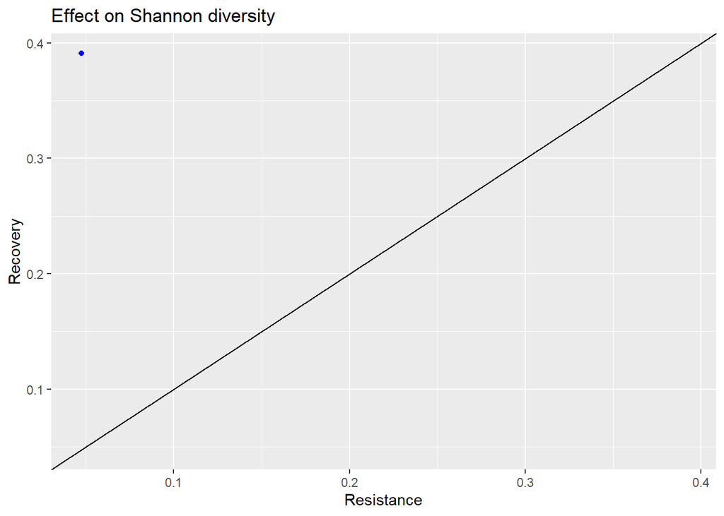

```r
temp_df <- data.frame(div_resist = effects_df$diversity[which(effects_df$time == heat_pulse_times[2])],
div_recov = effects_df$diversity[which(effects_df$time == heat_pulse_times[3])])

ggplot(temp_df, aes(x = div_resist, y = div_recov)) +
  geom_point(color = "blue") +
  geom_abline(intercept = 0, slope = 1, color = "black") +
  xlim(range(c(temp_df$div_resist, temp_df$div_recov))) +
  ylim(range(c(temp_df$div_resist, temp_df$div_recov))) +
  labs(title = "Effect on Shannon diversity", x="Resistance", y="Recovery")
```

# Analysis

Great! Now we can analyze what happens under the 3 scenarios: null hypothesis, trade-ups, trade-offs. We keep the timings of the heat pulse and the ambient growth rates constant. And we see what happens as the growth rates under extreme heat are changed. In particular, we can just focus on what happens as `sp2_extreme` changes.

## Null hypothesis

So I’m probably over-thinking it but I’m not sure what I mean by the null hypothesis: is it strictly that the lines are parallel (i.e., the distance between the 2 lines is the same under ambient temperature as under the extreme temperature) OR is it that the ratio of how much slower the slow grower grows than the fast grower is fixed?

### logistic, positive growth

Either way let’s see what happens as we go down to very small positive growth values for the slow grower. We expect that all of these should show a coupling of resistance and recovery…

```r
# keep all of these parameter values fixed:
State <- c(N1=0.001, N2=0.001)
heat_pulse_times <- c(5,18,30)
carrying_cap <- 10^6
sp1_ambient <- 0.97
sp1_extreme <- 0.46
# just modify these two parameter values:
sp2_ambient <- 0.76
sp2_extreme <- 0.25

plot_muSchematic(fast_ambient = sp1_ambient, fast_extreme = sp1_extreme,
                 slo_ambient = sp2_ambient, slo_extreme = sp2_extreme,
                 plot_title = "H0: same distance btw sp1 & sp2")
```

[output not shown]

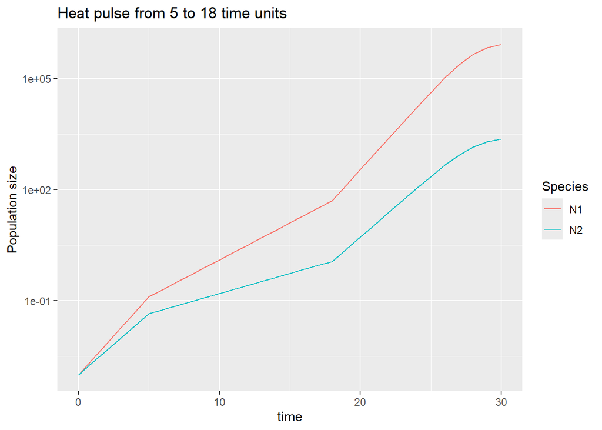

```r
# simulate the community with heat pulse
simEX <- sim_pulse(times=heat_pulse_times, init=State, K=carrying_cap,
                   mu_ambient=c(mu1=sp1_ambient, mu2=sp2_ambient), mu_extreme=c(mu1=sp1_extreme, mu2=sp2_extreme))

# plot the example under heat pulse conditions
ggplot(pivot_longer(simEX, cols = N1:N2),
       aes(x=time, y=value, colour=name)) +
  geom_line() +
  labs(title = "Heat pulse from 5 to 18 time units", y="Population size", colour = "Species") +
  scale_y_log10()
```

```r
# simulate the community WITHOUT heat pulse (i.e., no heat control)
simCTRL <- sim_1temp(time = 0:heat_pulse_times[3],
                   init = State,
                   params = c(K=carrying_cap, mu1=sp1_ambient, mu2=sp2_ambient))
# plot the no heat control:
ggplot(pivot_longer(simCTRL, cols = N1:N2),
       aes(x=time, y=value, colour=name)) +
  geom_line() +
  labs(title = "No heat pulse", y="Population size", colour = "Species") +
  scale_y_log10()
```

[output not shown]

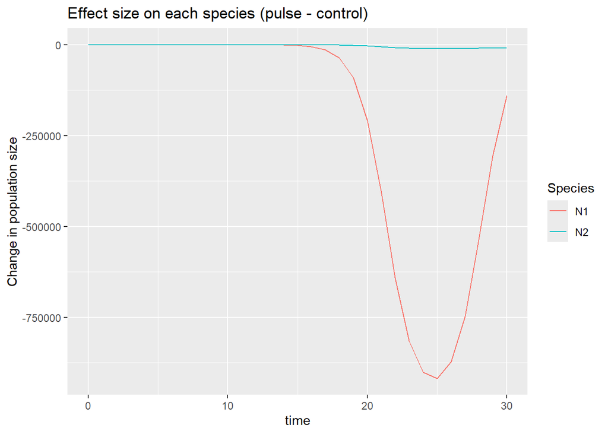

```r
################ let's look at the effect size in different ways:
effects_df <- heatVScontrol_effect(simdata_heat=simEX, simdata_control=simCTRL)

# plot per species
ggplot(effects_df %>%
         select(time, N1, N2) %>% pivot_longer(cols = N1:N2),
       aes(x=time, y=value, colour=name)) +
  geom_line() +
  labs(title = "Effect size on each species (pulse - control)", y="Change in population size", colour = "Species")
```

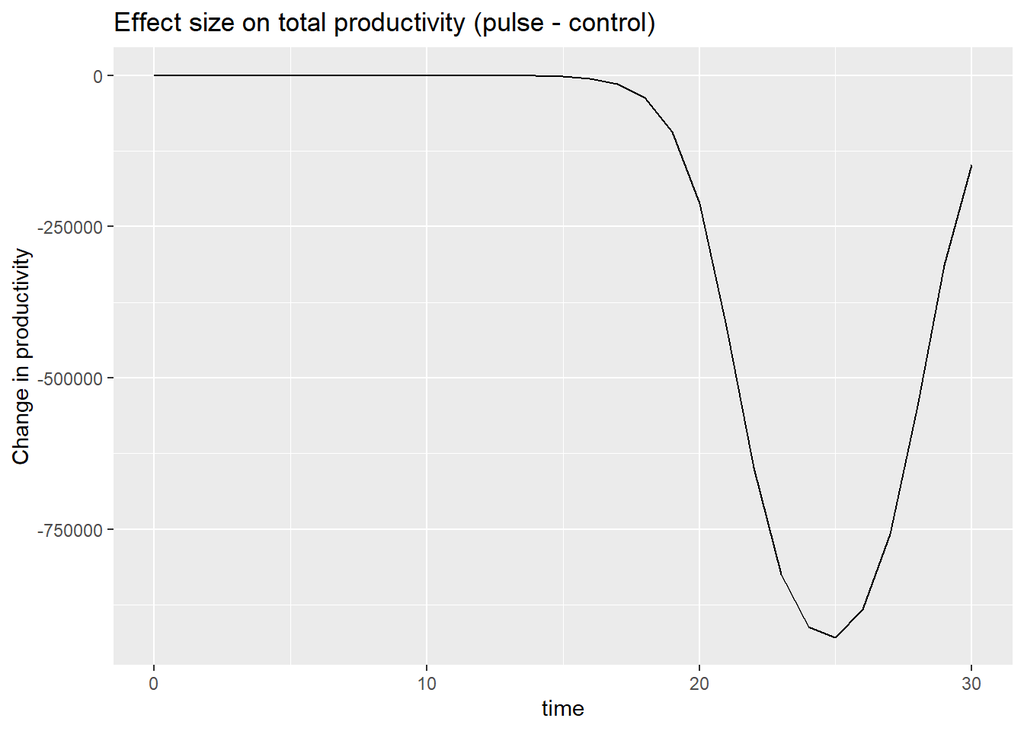

```r
# total productivity
ggplot(effects_df %>%
         select(time, productivity),
       aes(x=time, y=productivity)) +
  geom_line() +
  labs(title = "Effect size on total productivity (pulse - control)", y="Change in productivity")
```

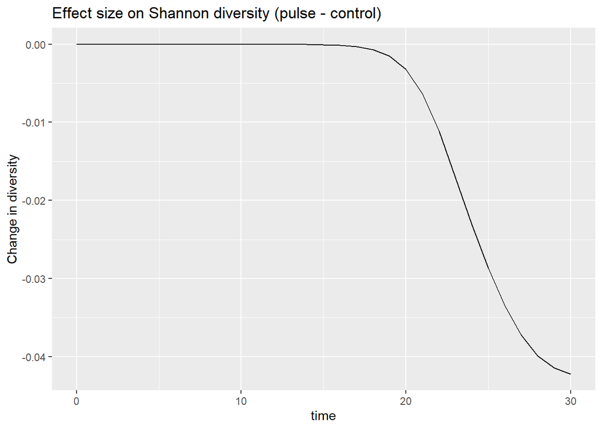

```r
# Shannon diversity
ggplot(effects_df %>%
         select(time, diversity),
       aes(x=time, y=diversity)) +
  geom_line() +
  labs(title = "Effect size on Shannon diversity (pulse - control)", y="Change in diversity")
```

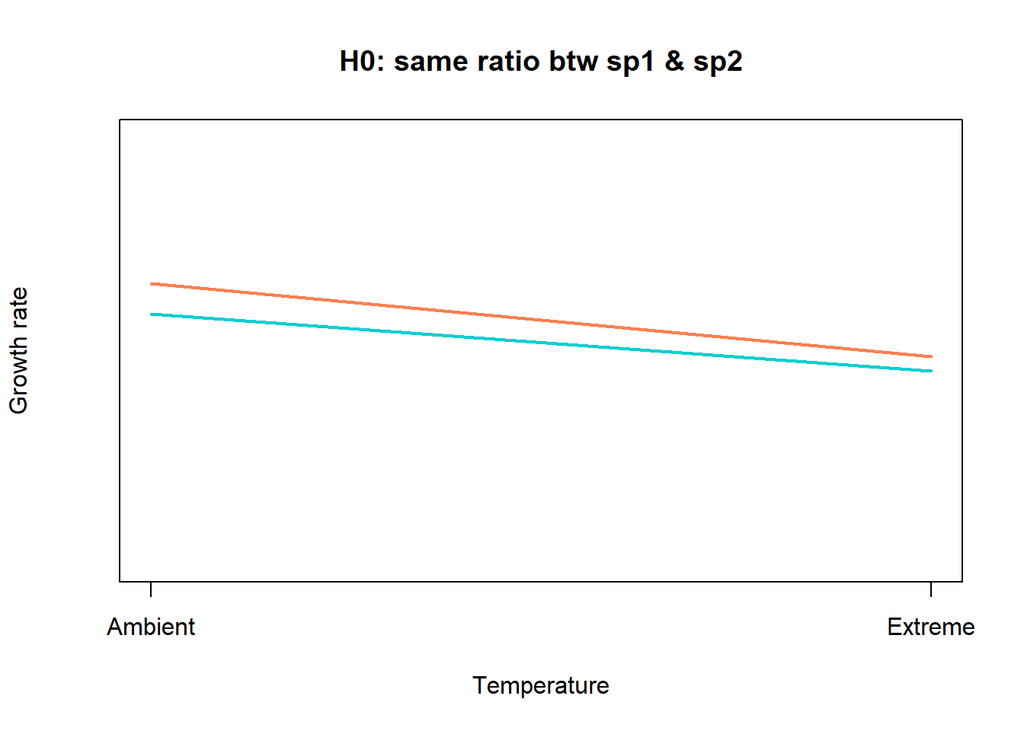

```r
# finally, we store the resistance vs recovery values for both productivity and diversity
RR_df <- data.frame(prod_resist = effects_df$productivity[which(effects_df$time == heat_pulse_times[2])],
                    prod_recov = effects_df$productivity[which(effects_df$time == heat_pulse_times[3])],
                    div_resist = effects_df$diversity[which(effects_df$time == heat_pulse_times[2])],
                    div_recov = effects_df$diversity[which(effects_df$time == heat_pulse_times[3])],
                    spF_ambient = sp1_ambient,
                    spF_extreme = sp1_extreme,
                    spS_ambient = sp2_ambient,
                    spS_extreme = sp2_extreme,
                    hypoth = "H0: same distance")
# clear memory
rm(simEX, simCTRL, effects_df)


##################################### Try again:
sp2_ambient <- 0.76
sp2_extreme <- 0.36

plot_muSchematic(fast_ambient = sp1_ambient, fast_extreme = sp1_extreme,
                 slo_ambient = sp2_ambient, slo_extreme = sp2_extreme,
                 plot_title = "H0: same ratio btw sp1 & sp2")
```

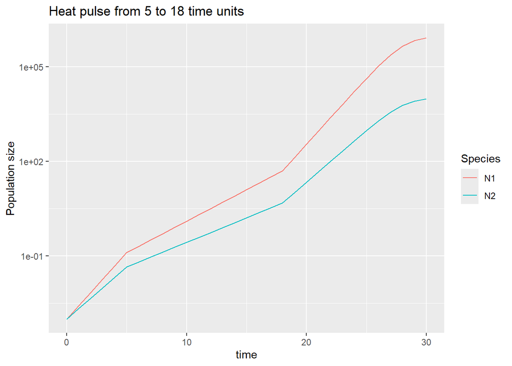

```r
# simulate the community with heat pulse
simEX <- sim_pulse(times=heat_pulse_times, init=State, K=carrying_cap,
                   mu_ambient=c(mu1=sp1_ambient, mu2=sp2_ambient), mu_extreme=c(mu1=sp1_extreme, mu2=sp2_extreme))

# plot the example under heat pulse conditions
ggplot(pivot_longer(simEX, cols = N1:N2),
       aes(x=time, y=value, colour=name)) +
  geom_line() +
  labs(title = "Heat pulse from 5 to 18 time units", y="Population size", colour = "Species") +
  scale_y_log10()
```

```r
# simulate the community WITHOUT heat pulse (i.e., no heat control)
simCTRL <- sim_1temp(time = 0:heat_pulse_times[3],
                   init = State,
                   params = c(K=carrying_cap, mu1=sp1_ambient, mu2=sp2_ambient))
# plot the no heat control:
ggplot(pivot_longer(simCTRL, cols = N1:N2),
       aes(x=time, y=value, colour=name)) +
  geom_line() +
  labs(title = "No heat pulse", y="Population size", colour = "Species") +
  scale_y_log10()
```

[output not shown]

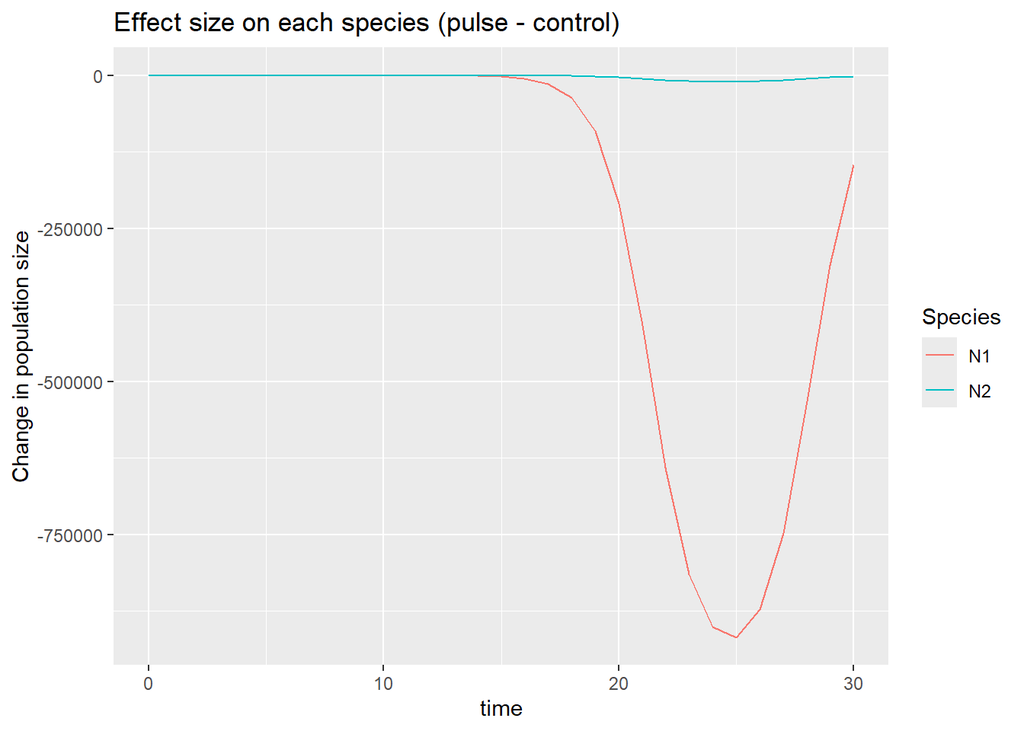

```r
################ let's look at the effect size in different ways:
effects_df <- heatVScontrol_effect(simdata_heat=simEX, simdata_control=simCTRL)

# plot per species
ggplot(effects_df %>%
         select(time, N1, N2) %>% pivot_longer(cols = N1:N2),
       aes(x=time, y=value, colour=name)) +
  geom_line() +
  labs(title = "Effect size on each species (pulse - control)", y="Change in population size", colour = "Species")
```

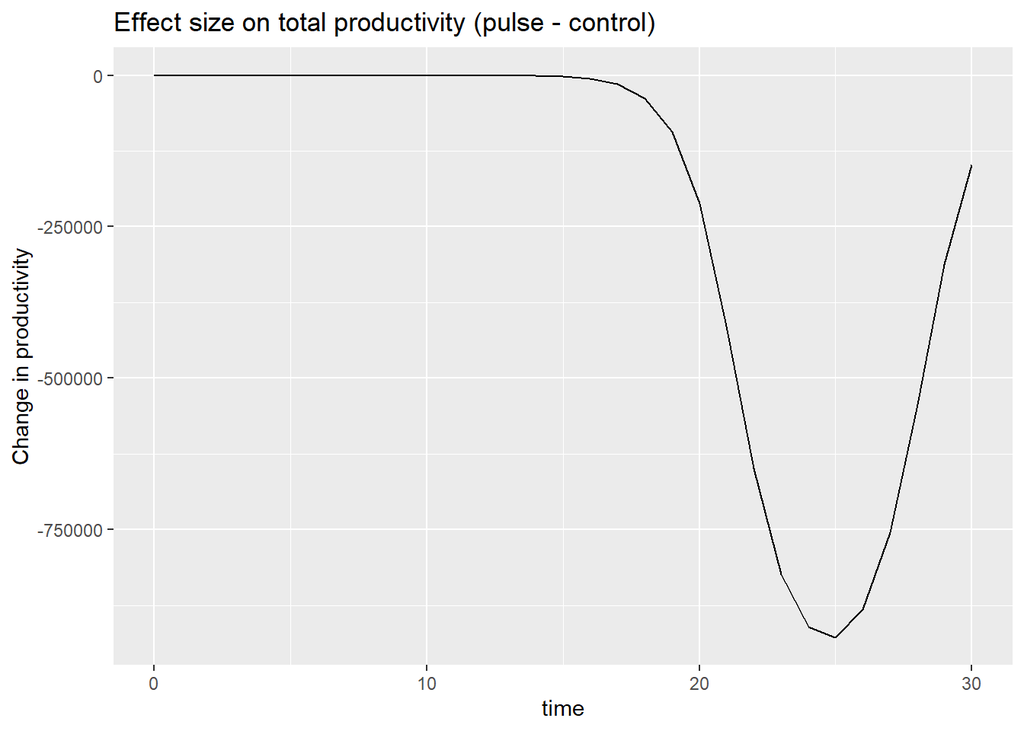

```r
# total productivity
ggplot(effects_df %>%
         select(time, productivity),
       aes(x=time, y=productivity)) +
  geom_line() +
  labs(title = "Effect size on total productivity (pulse - control)", y="Change in productivity")
```

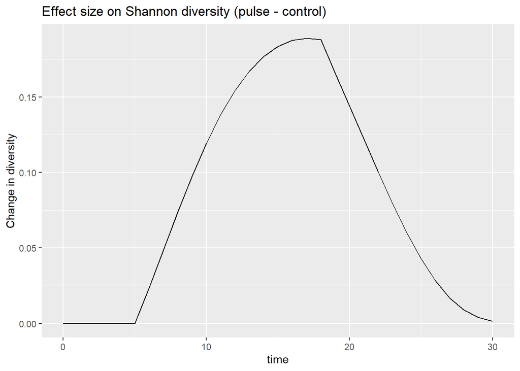

```r
# Shannon diversity
ggplot(effects_df %>%
         select(time, diversity),
       aes(x=time, y=diversity)) +
  geom_line() +
  labs(title = "Effect size on Shannon diversity (pulse - control)", y="Change in diversity")
```

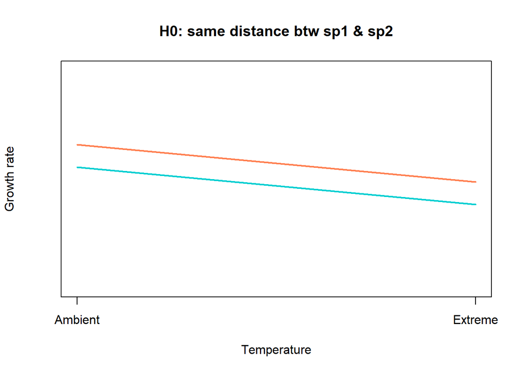

```r
# finally, we store the resistance vs recovery values for both productivity and diversity
temp <- data.frame(prod_resist = effects_df$productivity[which(effects_df$time == heat_pulse_times[2])],
                    prod_recov = effects_df$productivity[which(effects_df$time == heat_pulse_times[3])],
                    div_resist = effects_df$diversity[which(effects_df$time == heat_pulse_times[2])],
                    div_recov = effects_df$diversity[which(effects_df$time == heat_pulse_times[3])],
                    spF_ambient = sp1_ambient,
                    spF_extreme = sp1_extreme,
                    spS_ambient = sp2_ambient,
                    spS_extreme = sp2_extreme,
                    hypoth = "H0: same ratio")
RR_df <- rbind(RR_df, temp)
rm(temp)
# clear memory
rm(simEX, simCTRL, effects_df)


##################################### And again:
sp2_ambient <- 0.66
sp2_extreme <- 0.15

plot_muSchematic(fast_ambient = sp1_ambient, fast_extreme = sp1_extreme,
                 slo_ambient = sp2_ambient, slo_extreme = sp2_extreme,
                 plot_title = "H0: same distance btw sp1 & sp2")
```

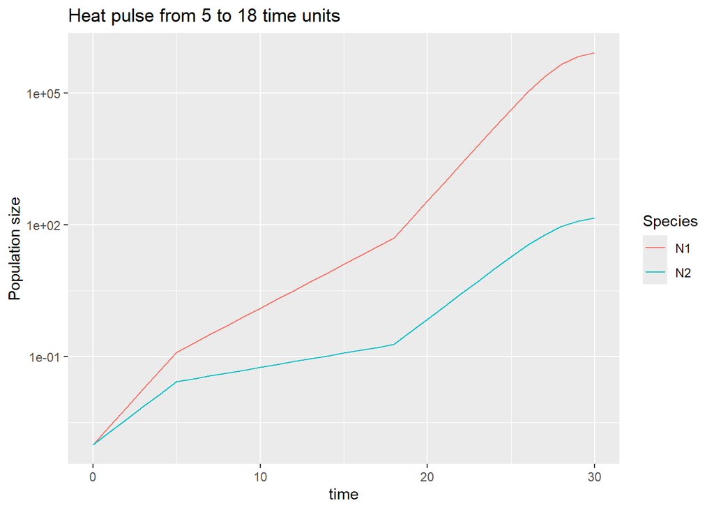

```r
# simulate the community with heat pulse
simEX <- sim_pulse(times=heat_pulse_times, init=State, K=carrying_cap,
                   mu_ambient=c(mu1=sp1_ambient, mu2=sp2_ambient), mu_extreme=c(mu1=sp1_extreme, mu2=sp2_extreme))

# plot the example under heat pulse conditions
ggplot(pivot_longer(simEX, cols = N1:N2),
       aes(x=time, y=value, colour=name)) +
  geom_line() +
  labs(title = "Heat pulse from 5 to 18 time units", y="Population size", colour = "Species") +
  scale_y_log10()
```

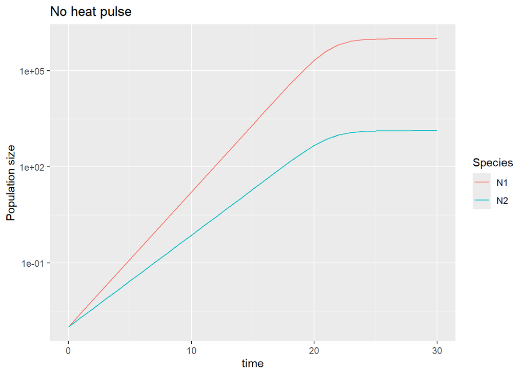

```r
# simulate the community WITHOUT heat pulse (i.e., no heat control)
simCTRL <- sim_1temp(time = 0:heat_pulse_times[3],
                   init = State,
                   params = c(K=carrying_cap, mu1=sp1_ambient, mu2=sp2_ambient))
# plot the no heat control:
ggplot(pivot_longer(simCTRL, cols = N1:N2),
       aes(x=time, y=value, colour=name)) +
  geom_line() +
  labs(title = "No heat pulse", y="Population size", colour = "Species") +
  scale_y_log10()
```

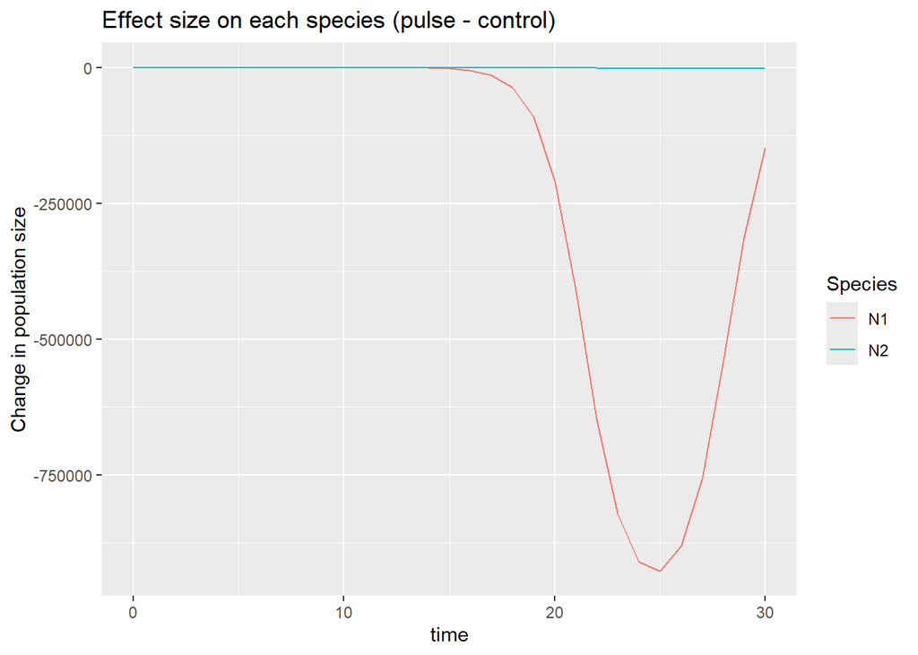

```r
################ let's look at the effect size in different ways:
effects_df <- heatVScontrol_effect(simdata_heat=simEX, simdata_control=simCTRL)

# plot per species
ggplot(effects_df %>%
         select(time, N1, N2) %>% pivot_longer(cols = N1:N2),
       aes(x=time, y=value, colour=name)) +
  geom_line() +
  labs(title = "Effect size on each species (pulse - control)", y="Change in population size", colour = "Species")
```

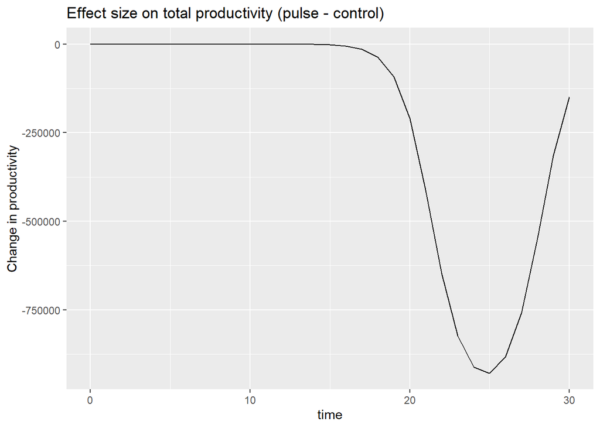

```r
# total productivity
ggplot(effects_df %>%
         select(time, productivity),
       aes(x=time, y=productivity)) +
  geom_line() +
  labs(title = "Effect size on total productivity (pulse - control)", y="Change in productivity")
```

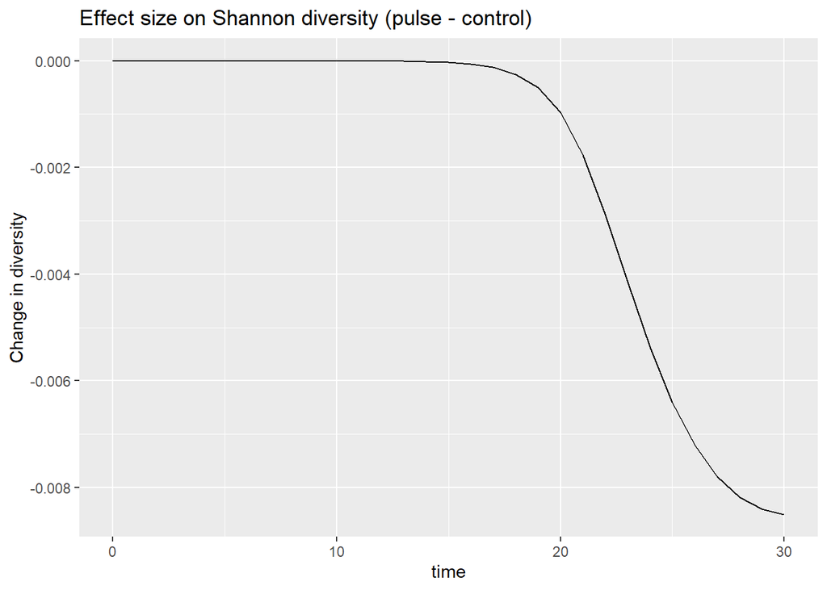

```r
# Shannon diversity
ggplot(effects_df %>%
         select(time, diversity),
       aes(x=time, y=diversity)) +
  geom_line() +
  labs(title = "Effect size on Shannon diversity (pulse - control)", y="Change in diversity")
```

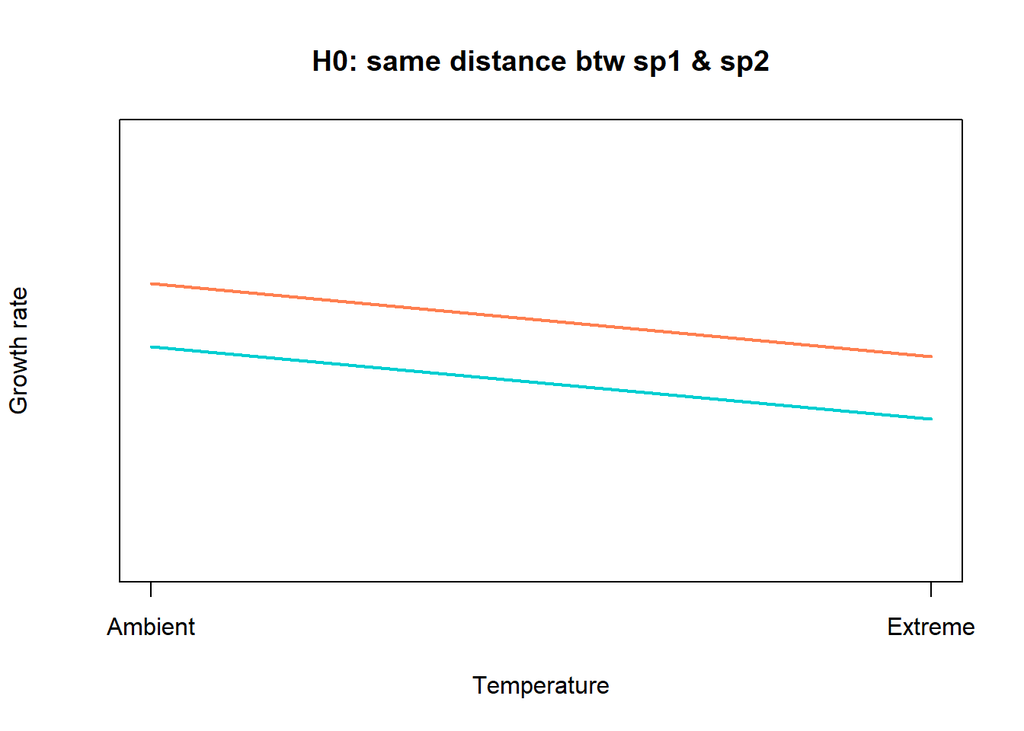

```r
# finally, we store the resistance vs recovery values for both productivity and diversity
temp <- data.frame(prod_resist = effects_df$productivity[which(effects_df$time == heat_pulse_times[2])],
                    prod_recov = effects_df$productivity[which(effects_df$time == heat_pulse_times[3])],
                    div_resist = effects_df$diversity[which(effects_df$time == heat_pulse_times[2])],
                    div_recov = effects_df$diversity[which(effects_df$time == heat_pulse_times[3])],
                    spF_ambient = sp1_ambient,
                    spF_extreme = sp1_extreme,
                    spS_ambient = sp2_ambient,
                    spS_extreme = sp2_extreme,
                    hypoth = "H0: same distance")
RR_df <- rbind(RR_df, temp)
rm(temp)
# clear memory
rm(simEX, simCTRL, effects_df)


##################################### aaaaand yet again:
sp2_ambient <- 0.53
sp2_extreme <- 0.02

plot_muSchematic(fast_ambient = sp1_ambient, fast_extreme = sp1_extreme,
                 slo_ambient = sp2_ambient, slo_extreme = sp2_extreme,
                 plot_title = "H0: same distance btw sp1 & sp2")
```

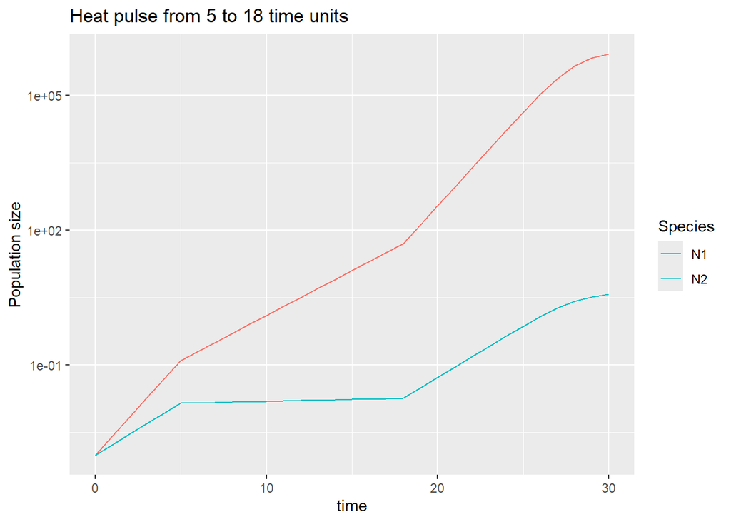

```r
# simulate the community with heat pulse
simEX <- sim_pulse(times=heat_pulse_times, init=State, K=carrying_cap,
                   mu_ambient=c(mu1=sp1_ambient, mu2=sp2_ambient), mu_extreme=c(mu1=sp1_extreme, mu2=sp2_extreme))

# plot the example under heat pulse conditions
ggplot(pivot_longer(simEX, cols = N1:N2),
       aes(x=time, y=value, colour=name)) +
  geom_line() +
  labs(title = "Heat pulse from 5 to 18 time units", y="Population size", colour = "Species") +
  scale_y_log10()
```